# July 2024 Bumps: Reddit Group Demographic Survey

July 2024 Bumps: Reddit Group Demographic Survey January 20, 2024

## Introduction

Welcome to the results of the demographic survey for the reddit group “July 2024 Bumps.” This is a group of people from all over the world who are expecting little ones to join them in approximately July 2024. Thank you for contributing to the survey!

Note that some of the data allowed free-form / unstructured responses (e.g., the ethnicity question; the pets question) and therefore did not lend itself well to tabular summary. In these cases, the authors have summarized major trends in writing.

## Part I: Demographic summary

A total of 811 members of the subreddit community contributed to the survey. Some questions may have fewer total respondents if some participants chose not to respond to every item.

Respondents range from 20 years old to 43 years old. The average (mean and median) ages are 32 years.

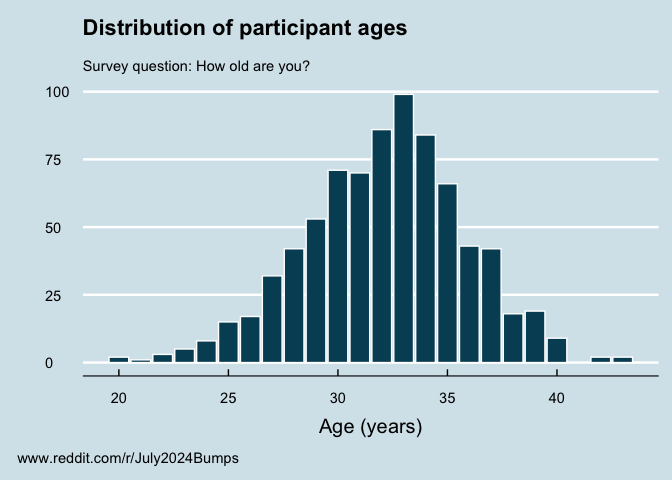

Of the respondents, 615 identify as “Caucasian/White” only. Of the 196 remaining respondents, 37 identify as East Asian, 24 as Latino/Hispanic, 22 as Caucasian/White and Latino/Hispanic, 22 as South Asian, 12 as African/Black, 11 as Caucasian/White and East Asian, 7 as African/Black and Caucasian/White, 6 as Middle Eastern, and 4 as Caribbean. Other identities in lower frequencies included but are not limited to: Ashkenazi Jewish, Biracial, West Asian, and combinations of the other ethnicities. 22 participants did not to respond to this question.

Of the respondents, 613 are employed full-time, 53 are employed part-time, 61 are homemakers/stay-at-home parents, 41 are self-employed, and the remainder (not necessarily mutually exclusive with other categories) are students, in the military, on maternity leave, and/or unemployed or on medical leave.

### Gender identity, sexual orientation, and family structure of respondents

Of the respondents, 796 identify as female, 6 as male, 5 as nonbinary, and 1 as a trans man.

702 respondents identify as straight, 11 as gay, 75 as bisexual, 5 as asexual, 4 as queer, 3 as pansexual, 1 as bisexual/demisexual, and 1 as demisexual.

For those who are in a romantic relationship with the other parent, 778 are in a relationship with an opposite sex partner, 20 are in a same sex relationship, 2 are trans men with cis female partners, 1 is with a non-binary partner, and 1 is in a polyamorous relationship with both same and opposite sex partners.

488 respondents live with their partner or partners, 279 live with partners, children and stepchildren, and 44 respondents described other living arrangements, including extended family members, roommates, friends, and nannies/au pairs.

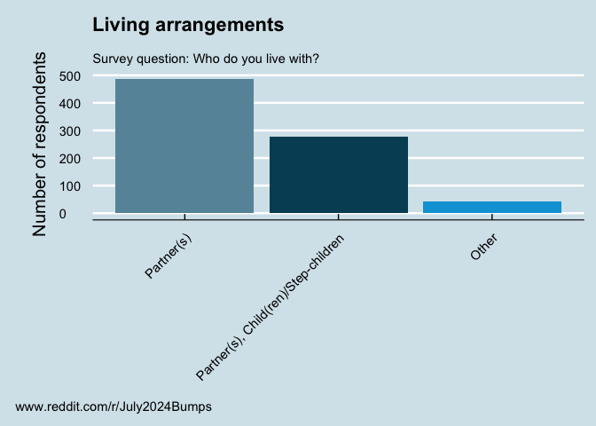

Of the respondents, 160 have no pets, and 638 have at least one pet. Dogs and cats are the most common, but some people also report having: reptiles, birds, rabbits, guinea pigs, hamsters, sugar gliders, fish, horses, chickens, cows, pigs, and even hermit crabs!

### Geography of respondents

More than 80% of respondents live in North America, but there are individuals from every major continent including Africa (2), Asia (6), Latin America (2), Europe/UK/Ireland (73) and Australia/New Zealand (25).

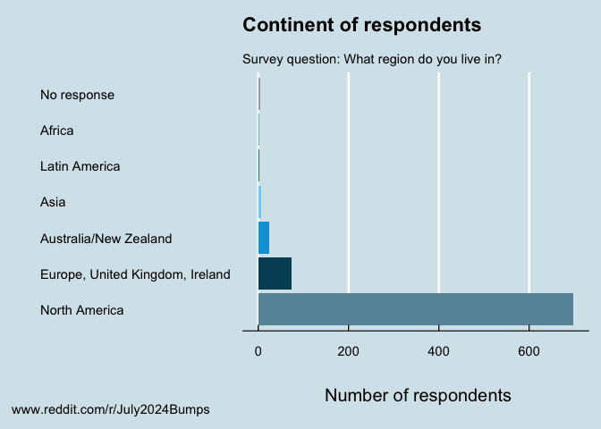

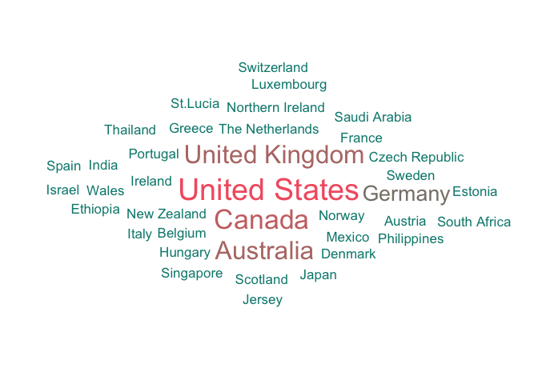

## Part II: About pregnancy

When asked “Are you currently pregnant?”, 804 responded yes, and 7 responded “No, but my partner is pregnant.”

Of the respondents, 710 (88%) were actively trying to conceive and 95 were not.

Most respondents are having their first (502) or second (252) children, but 40 are having their third, 10 are having their 4th, 2 are having their 5th, and one is having their 8th child!

Four women identified as a second time mom but first time parent due to a prior stillbirth, identified as “other” in the graphic below for brevity.

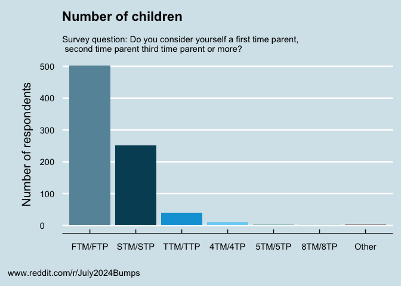

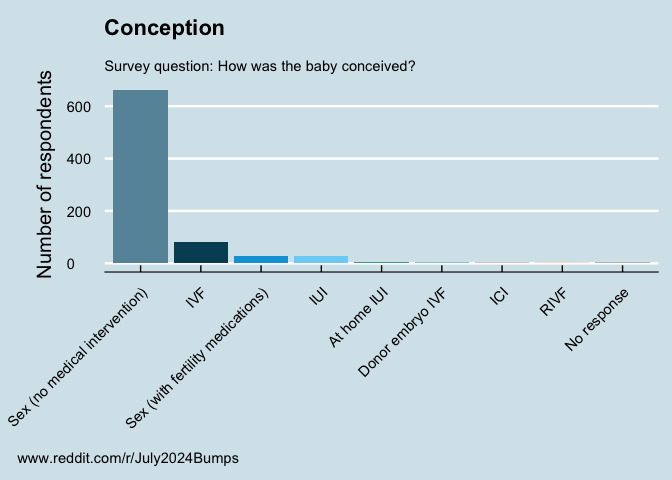

Most respondents were pregnant within 1 to 3 months of trying to conceive, but 4 - 6 months, 7 - 12 months, and more than 12 months were all very common as well.

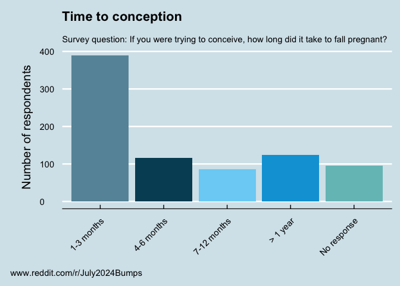

Most respondents (87%) got their positive pregnancy test at 3 or 4 weeks pregnant, around or right before the start of an expected menstrual cycle.

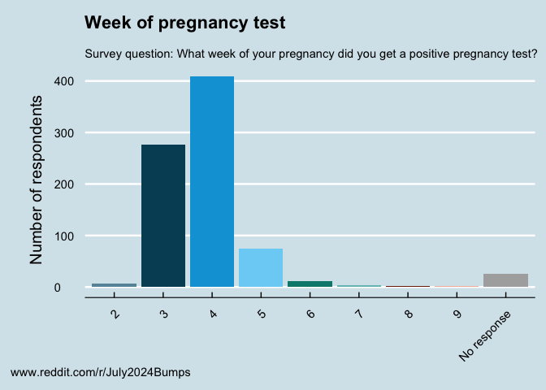

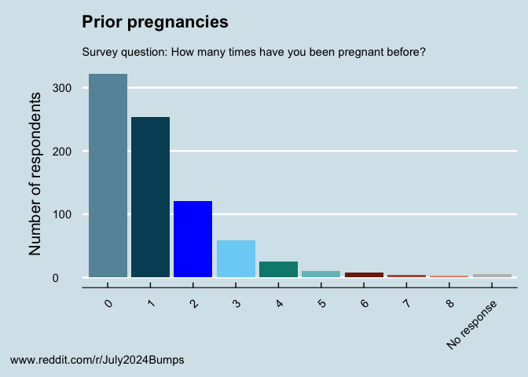

Even with the large number of first-time pregnancies, many (40%) of the other expecting parents have experienced one or more prior losses.

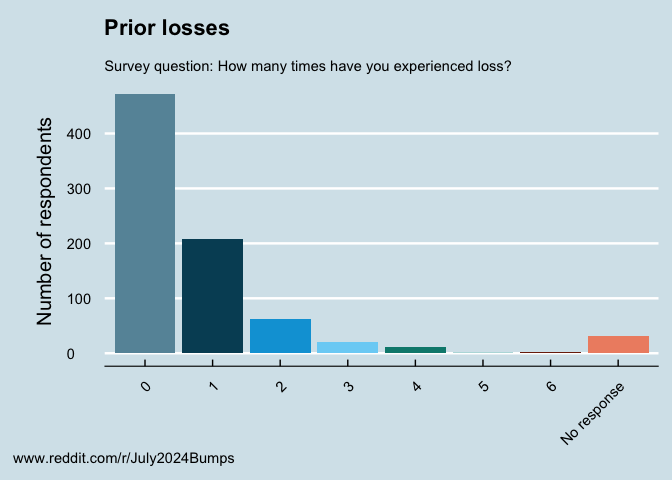

### Part III: About babies and children

Most respondents are due in July 2024, but some are expecting in June or August. Note that many of the due dates were reported as 2023 and these were assumed to be 2024.

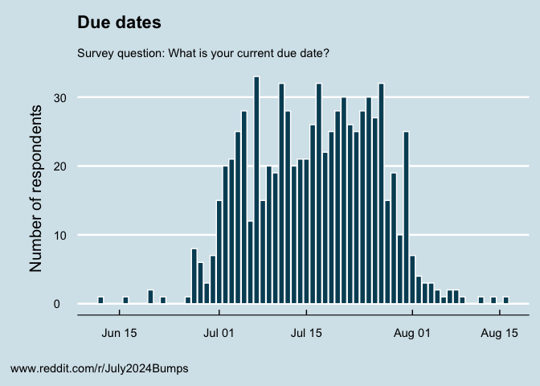

When asked “How many babies are you currently expecting?”, 798 respondents are expecting one baby, 11 are expecting twins, and one is expecting triplets.

In alignment with the results on first pregnancies above, most respondents having zero living children, but many have 1, 2 or more living children.

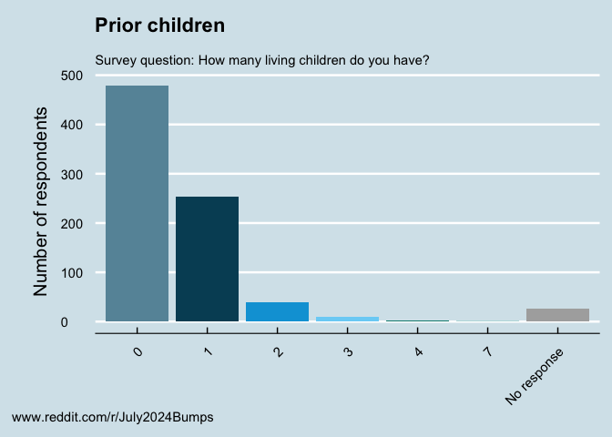

When asked “Are you finding out the sex of the baby/babies you are expecting?” 686 said yes and 121 said no.

Among singleton pregnancies, there is a very even split (171 boys to 172 girls); 468 did not respond, either because they are not finding out prior to birth and/or because they have not yet had the opportunity to find out.

For those who are having a multiples pregnancy, 1 reported expecting one of each, 4 reported expecting two girls, and the others did not respond.

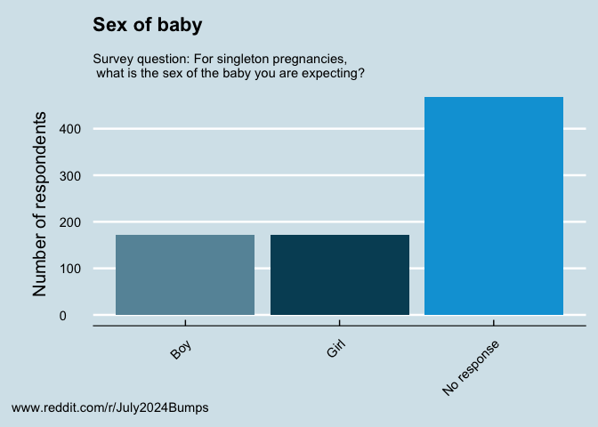

### Part IV: Online activity

Of the respondents, 54 are also in the Facebook or Discord groups, and 751 are not. Most respondents were occasional posters (351) or lurkers (298) before joining this group, although there are some frequent posters (117) and some were completely new to reddit (43) prior to joining this group.

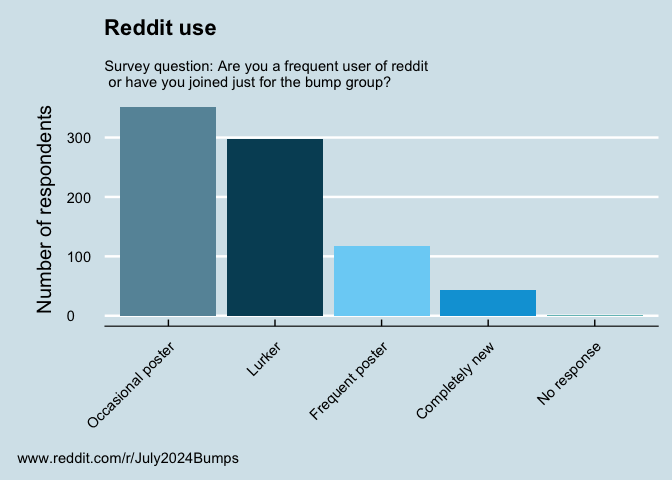

Most respondents heard about this reddit group from other pregnancy subreddits, such as /r/tryingforababy or r/pregnant, or belonging to previous bump groups. Online searching and word of mouth were also common. Regardless, welcome and we are glad you are here!

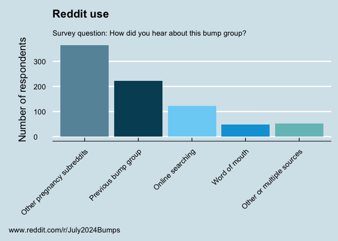

#### Thank you

*For more information on the data or analyses, please contact the moderators of /r/July2024Bumps. The cleaned dataset is available in .xlsx or .csv formats, or others (SPSS, SAS, etc) upon request, for members of this subreddit only. All analyses were done in R and scripts can be shared upon request.*